# Loan Data from Prosper

Alexander Barnes

========================================================

This dataset contains 113,937 loans with 81 variables for each loan, including loan amount, borrower rate (or interest rate), current loan status, borrower income, borrower employment status, borrower credit history, and the latest payment information. The data set was last updated on March 11, 2014.

# Univariate Plots Section

```
## [1] 113937     81
```

In this analysis, we will limit the amount of variables we analyze to 13 rather than 81 variables. The variables below were selected out of an interest to see any relationships and trends between them.

```
## [1] 113937     13
```

```
## 'data.frame':    113937 obs. of  13 variables:
##  $ Term                 : int  36 36 36 36 36 60 36 36 36 36 ...
##  $ LoanStatus           : Factor w/ 12 levels "Cancelled","Chargedoff",..: 3 4 3 4 4 4 4 4 4 4 ...
##  $ BorrowerRate         : num  0.158 0.092 0.275 0.0974 0.2085 ...
##  $ ProsperScore         : num  NA 7 NA 9 4 10 2 4 9 11 ...
##  $ EmploymentStatus     : Factor w/ 9 levels "","Employed",..: 9 2 4 2 2 2 2 2 2 2 ...
##  $ IsBorrowerHomeowner  : Factor w/ 2 levels "False","True": 2 1 1 2 2 2 1 1 2 2 ...
##  $ CreditScoreRangeLower: int  640 680 480 800 680 740 680 700 820 820 ...
##  $ CreditScoreRangeUpper: int  659 699 499 819 699 759 699 719 839 839 ...
##  $ OpenCreditLines      : int  4 14 NA 5 19 17 7 6 16 16 ...
##  $ AmountDelinquent     : num  472 0 NA 10056 0 ...
##  $ DebtToIncomeRatio    : num  0.17 0.18 0.06 0.15 0.26 0.36 0.27 0.24 0.25 0.25 ...
##  $ StatedMonthlyIncome  : num  3083 6125 2083 2875 9583 ...
##  $ MonthlyLoanPayment   : num  330 319 123 321 564 ...
```

I will try to order the factor levels of loan status and employment status by perceived level of benefit and risk for the loan company (from worst to best). I understand this may be subjective, but I want to see how the distributions and plots display with these variables ordered.

```
##  [1] "ChargedOff"             "Defaulted"
##  [3] "Cancelled"              "Past Due (>120 days)"
##  [5] "Past Due (91-120 days)" "Past Due (61-90 days)"
##  [7] "Past Due (31-60 days)"  "Past Due (16-30 days)"
##  [9] "Past Due (1-15 days)"   "FinalPaymentInProgress"
## [11] "Current"                "Completed"
```

```
## [1] "Not employed"  "No answer"     "Not available" "Other"
## [5] "Retired"       "Self-employed" "Part-time"     "Employed"
## [9] "Full-time"
```

```
##       Term                       LoanStatus     BorrowerRate
##  Min.   :12.00   Current              :56576   Min.   :0.0000
##  1st Qu.:36.00   Completed            :38074   1st Qu.:0.1340
##  Median :36.00   Defaulted            : 5018   Median :0.1840
##  Mean   :40.83   Past Due (1-15 days) :  806   Mean   :0.1928
##  3rd Qu.:36.00   Past Due (31-60 days):  363   3rd Qu.:0.2500
##  Max.   :60.00   (Other)              : 1108   Max.   :0.4975
##                  NA's                 :11992
##   ProsperScore        EmploymentStatus IsBorrowerHomeowner
##  Min.   : 1.00   Employed     :67322   False:56459
##  1st Qu.: 4.00   Full-time    :26355   True :57478
##  Median : 6.00   Self-employed: 6134
##  Mean   : 5.95   Not available: 5347
##  3rd Qu.: 8.00   Other        : 3806
##  Max.   :11.00   No answer    : 2255
##  NA's   :29084   (Other)      : 2718
##  CreditScoreRangeLower CreditScoreRangeUpper OpenCreditLines
##  Min.   :  0.0         Min.   : 19.0         Min.   : 0.00
##  1st Qu.:660.0         1st Qu.:679.0         1st Qu.: 6.00
##  Median :680.0         Median :699.0         Median : 9.00
##  Mean   :685.6         Mean   :704.6         Mean   : 9.26
##  3rd Qu.:720.0         3rd Qu.:739.0         3rd Qu.:12.00
##  Max.   :880.0         Max.   :899.0         Max.   :54.00
##  NA's   :591           NA's   :591           NA's   :7604
##  AmountDelinquent   DebtToIncomeRatio StatedMonthlyIncome
##  Min.   :     0.0   Min.   : 0.000    Min.   :      0
##  1st Qu.:     0.0   1st Qu.: 0.140    1st Qu.:   3200
##  Median :     0.0   Median : 0.220    Median :   4667
##  Mean   :   984.5   Mean   : 0.276    Mean   :   5608
##  3rd Qu.:     0.0   3rd Qu.: 0.320    3rd Qu.:   6825
##  Max.   :463881.0   Max.   :10.010    Max.   :1750003
##  NA's   :7622       NA's   :8554
##  MonthlyLoanPayment
##  Min.   :   0.0
##  1st Qu.: 131.6
##  Median : 217.7
##  Mean   : 272.5
##  3rd Qu.: 371.6
##  Max.   :2251.5
##
```

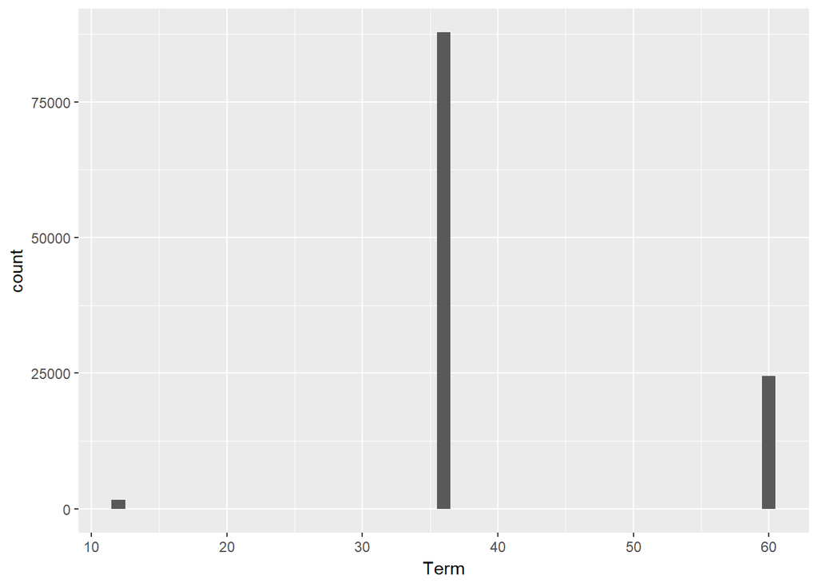

```
##
##    12    36    60
##  1614 87778 24545
```

There are only three distinct values to the loan term (12, 36, and 60 months). Going forward, we will treat the Term variable as a factor due to its categorical nature.

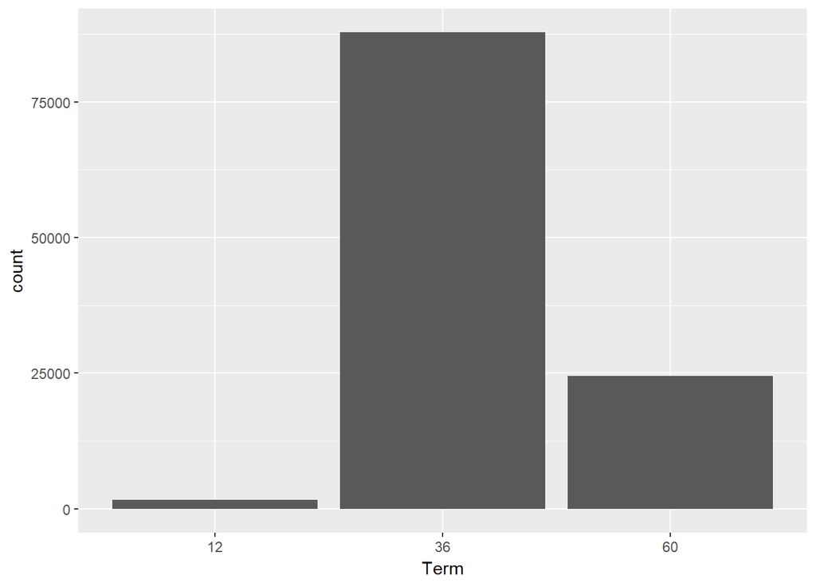

We can clearly see that most loans have a term of 36 months, and it’s much less common for a loan to have a term of 12 months.

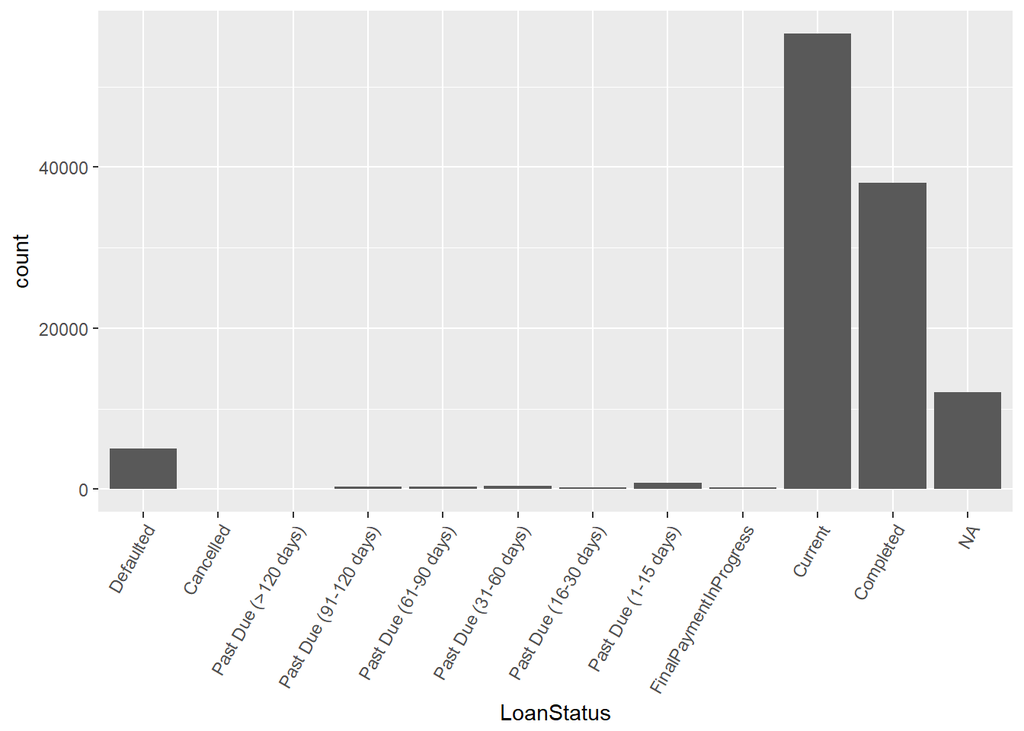

```
##
##             ChargedOff              Defaulted              Cancelled
##                      0                   5018                      5
##   Past Due (>120 days) Past Due (91-120 days)  Past Due (61-90 days)
##                     16                    304                    313
##  Past Due (31-60 days)  Past Due (16-30 days)   Past Due (1-15 days)
##                    363                    265                    806
## FinalPaymentInProgress                Current              Completed
##                    205                  56576                  38074
```

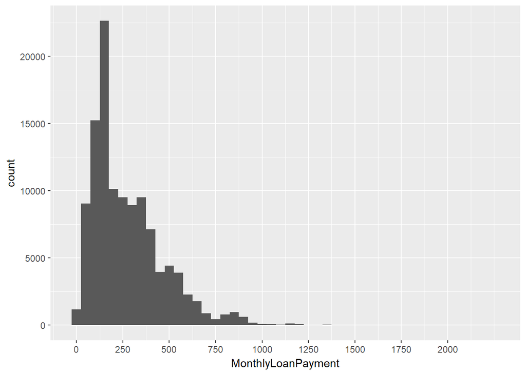

```
##    Min. 1st Qu.  Median    Mean 3rd Qu.    Max.
##     0.0   131.6   217.7   272.5   371.6  2251.5
```

Monthly loan payment is skewed to the right, with a minimum of $0 and a maximum of $2251.50. The minimum of $0 is interesting, as I expected all monthly loan payments to be greater than $0. I want to take a closer look at loans with monthly payments of $0 and those with high monthly payments.

```
##  Term                      LoanStatus   BorrowerRate     ProsperScore
##  12:161   Completed             :800   Min.   :0.0500   Min.   : 1.000
##  36:774   Defaulted             :131   1st Qu.:0.1224   1st Qu.: 6.000
##  60:  0   FinalPaymentInProgress:  4   Median :0.1875   Median : 8.000
##           ChargedOff            :  0   Mean   :0.1943   Mean   : 7.605
##           Cancelled             :  0   3rd Qu.:0.2635   3rd Qu.: 9.000
##           Past Due (>120 days)  :  0   Max.   :0.3600   Max.   :10.000
##           (Other)               :  0                    NA's   :451
##       EmploymentStatus IsBorrowerHomeowner CreditScoreRangeLower
##  Full-time    :444     False:558           Min.   :  0.0
##  Employed     :269     True :377           1st Qu.:580.0
##  Not available: 79                         Median :660.0
##  No answer    : 39                         Mean   :652.7
##  Self-employed: 35                         3rd Qu.:720.0
##  Part-time    : 35                         Max.   :860.0
##  (Other)      : 34                         NA's   :11
##  CreditScoreRangeUpper OpenCreditLines  AmountDelinquent
##  Min.   : 19.0         Min.   : 0.000   Min.   :    0.0
##  1st Qu.:599.0         1st Qu.: 4.000   1st Qu.:    0.0
##  Median :679.0         Median : 7.000   Median :    0.0
##  Mean   :671.7         Mean   : 7.543   Mean   :  878.4
##  3rd Qu.:739.0         3rd Qu.:10.000   3rd Qu.:   20.0
##  Max.   :879.0         Max.   :27.000   Max.   :81723.0
##  NA's   :11            NA's   :118      NA's   :118
##  DebtToIncomeRatio StatedMonthlyIncome MonthlyLoanPayment
##  Min.   : 0.0100   Min.   :     0      Min.   :0
##  1st Qu.: 0.1000   1st Qu.:  2750      1st Qu.:0
##  Median : 0.1700   Median :  4110      Median :0
##  Mean   : 0.2441   Mean   :  4836      Mean   :0
##  3rd Qu.: 0.2800   3rd Qu.:  5944      3rd Qu.:0
##  Max.   :10.0100   Max.   :108333      Max.   :0
##  NA's   :64
```

Subsetting the data to view loans with monthly payments of $0, we can see that categories such as CreditScoreRangeLower and StatedMonthlyIncome are lower than the overall median. Interestingly, the ProsperScore is higher than average for this subset.

```
##  Term                    LoanStatus  BorrowerRate      ProsperScore
##  12:8   Completed             :7    Min.   :0.05650   Min.   : 3.00
##  36:0   FinalPaymentInProgress:1    1st Qu.:0.06248   1st Qu.: 7.25
##  60:0   ChargedOff            :0    Median :0.07715   Median : 8.00
##         Defaulted             :0    Mean   :0.09001   Mean   : 7.50
##         Cancelled             :0    3rd Qu.:0.11865   3rd Qu.: 8.50
##         Past Due (>120 days)  :0    Max.   :0.14580   Max.   :10.00
##         (Other)               :0
##       EmploymentStatus IsBorrowerHomeowner CreditScoreRangeLower
##  Employed     :8       False:4             Min.   :740.0
##  Not employed :0       True :4             1st Qu.:755.0
##  No answer    :0                           Median :760.0
##  Not available:0                           Mean   :767.5
##  Other        :0                           3rd Qu.:780.0
##  Retired      :0                           Max.   :820.0
##  (Other)      :0
##  CreditScoreRangeUpper OpenCreditLines AmountDelinquent DebtToIncomeRatio
##  Min.   :759.0         Min.   : 6.00   Min.   :0        Min.   :0.1100
##  1st Qu.:774.0         1st Qu.: 7.75   1st Qu.:0        1st Qu.:0.1625
##  Median :779.0         Median : 9.50   Median :0        Median :0.1800
##  Mean   :786.5         Mean   :11.00   Mean   :0        Mean   :0.2137
##  3rd Qu.:799.0         3rd Qu.:13.25   3rd Qu.:0        3rd Qu.:0.2550
##  Max.   :839.0         Max.   :21.00   Max.   :0        Max.   :0.3900
##
##  StatedMonthlyIncome MonthlyLoanPayment
##  Min.   : 7292       Min.   :2112
##  1st Qu.:12333       1st Qu.:2144
##  Median :18125       Median :2159
##  Mean   :16589       Mean   :2170
##  3rd Qu.:20208       3rd Qu.:2189
##  Max.   :25000       Max.   :2252
##
```

Subsetting the data to view loans with monthly payments over $2000, it seems that the borrower generally has a high stated monthly income, has no amount delinquent, is employed, and has a high credit score. Also, the terms are all 12 months and the borrower rates are all under 0.15. The borrowers in these loans appear to be “low risk” borrowers as the higher median Prosper Score indicates.

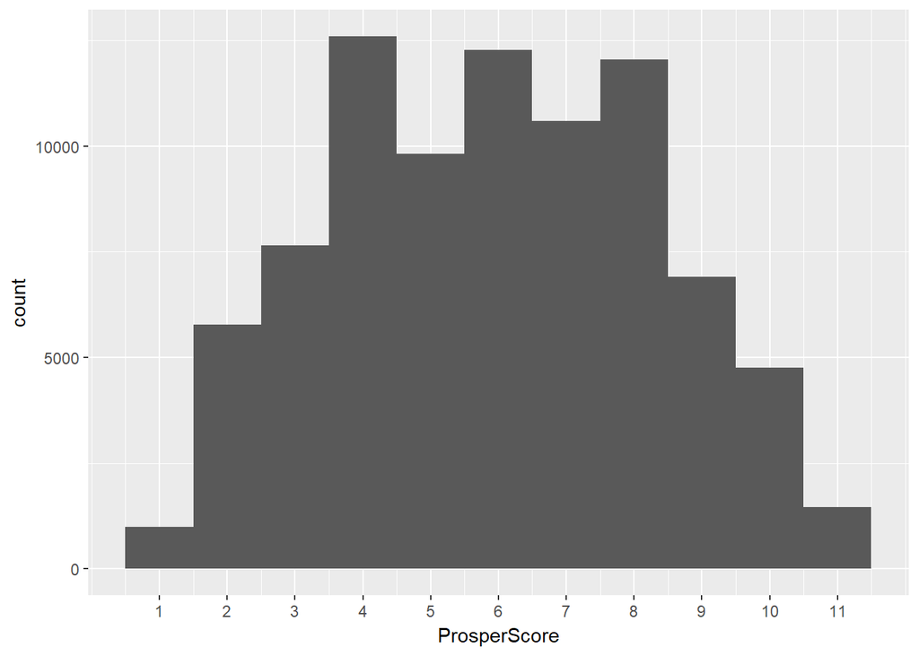

The Prosper Score appears to be a normal distribution. The plot above excludes any ‘NA’ values. The Prosper Score is also supposed to range from 1-10, so the scores of 11 were unexpected. I’m hesitant to treat a score of 11 as the best score since it may be an entry error. Let us subset the data to see if there is a trend in the loans with a Prosper Score of 11 and if the data is trustworthy.

```
##  Term                       LoanStatus    BorrowerRate      ProsperScore
##  12:   0   Current               :1419   Min.   :0.06050   Min.   :11
##  36:1049   Completed             :  31   1st Qu.:0.06590   1st Qu.:11
##  60: 407   FinalPaymentInProgress:   3   Median :0.08690   Median :11
##            Defaulted             :   1   Mean   :0.09328   Mean   :11
##            Past Due (61-90 days) :   1   3rd Qu.:0.10990   3rd Qu.:11
##            Past Due (1-15 days)  :   1   Max.   :0.19500   Max.   :11
##            (Other)               :   0
##       EmploymentStatus IsBorrowerHomeowner CreditScoreRangeLower
##  Employed     :1365    False:483           Min.   :640
##  Self-employed:  43    True :973           1st Qu.:700
##  Other        :  34                        Median :720
##  Full-time    :  14                        Mean   :732
##  Not employed :   0                        3rd Qu.:760
##  No answer    :   0                        Max.   :840
##  (Other)      :   0
##  CreditScoreRangeUpper OpenCreditLines AmountDelinquent DebtToIncomeRatio
##  Min.   :659           Min.   : 2.00   Min.   :     0   Min.   :0.0200
##  1st Qu.:719           1st Qu.: 8.00   1st Qu.:     0   1st Qu.:0.1300
##  Median :739           Median :11.00   Median :     0   Median :0.1900
##  Mean   :751           Mean   :11.32   Mean   :   298   Mean   :0.2007
##  3rd Qu.:779           3rd Qu.:14.00   3rd Qu.:     0   3rd Qu.:0.2500
##  Max.   :859           Max.   :38.00   Max.   :106071   Max.   :0.5800
##                                                         NA's   :44
##  StatedMonthlyIncome MonthlyLoanPayment
##  Min.   : 1200       Min.   :  43.47
##  1st Qu.: 5417       1st Qu.: 243.56
##  Median : 7500       Median : 402.31
##  Mean   : 8850       Mean   : 424.04
##  3rd Qu.:10833       3rd Qu.: 581.40
##  Max.   :76667       Max.   :1162.33
##
```

The summary of loans with a Prosper Score of 11 do seem to indicate borrowers that are low risk. The median StatedMonthlyIncome and OpenCreditLines are higher than the overall median. I think this data can be trusted and used.

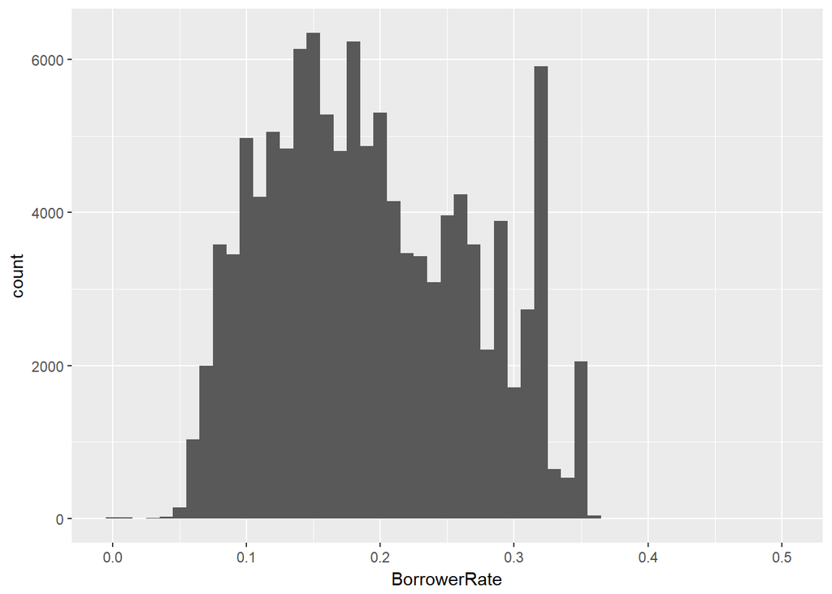

Borrower Rate has a fairly normal distribution, but there is a second peak around 0.31. The Prosper Score and Borrower Rate are both generated values, and I’m interested in exploring which variables affect these values.

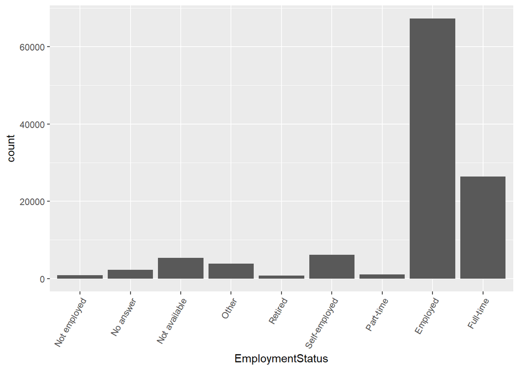

Almost all of the borrowers are employed. A limitation of this dataset that can be recognized here is that the data is only for those who applied for a loan and were approved. The “riskier”" loan applicants (unemployed) that were denied loans are not a part of this dataset.

I also wonder if leaving the response blank, or the unclear responses of “Not available” and “Other” affect the borrower’s interest rate and Prosper score.

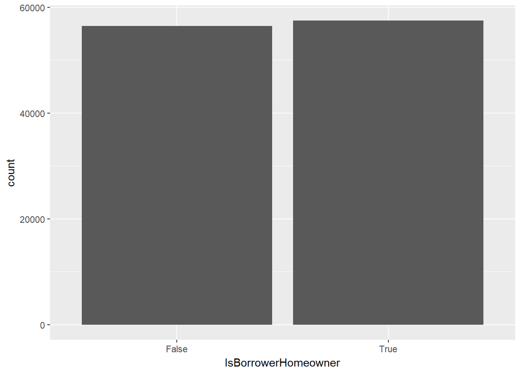

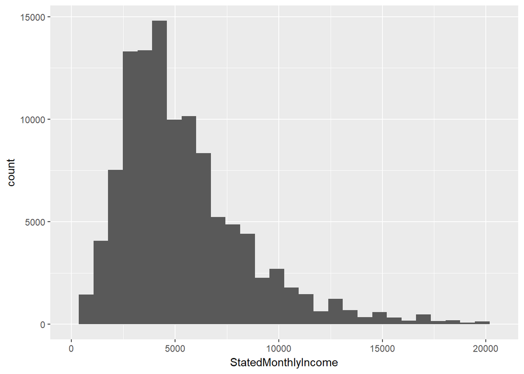

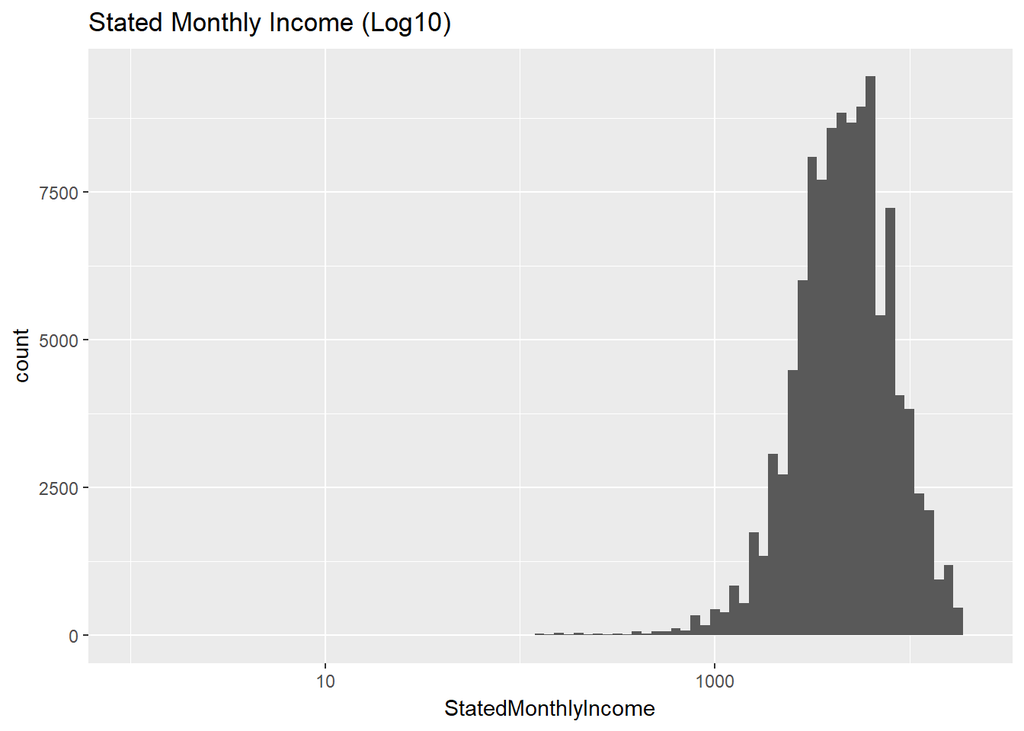

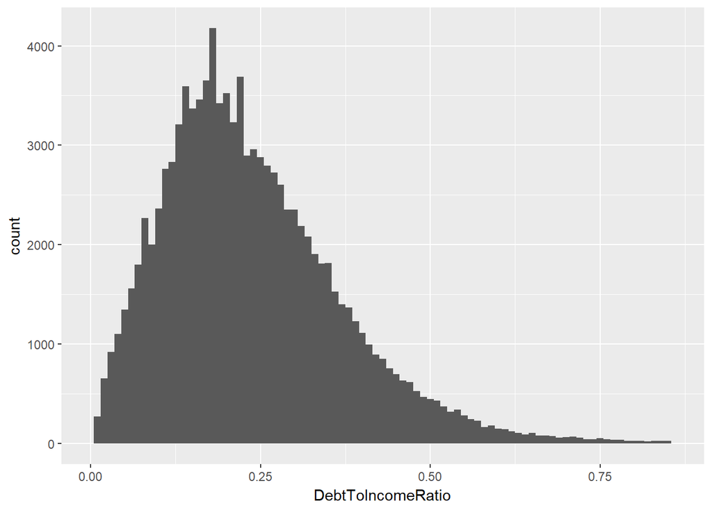

There is an even split between homeowners and non-homeowners. Does being a homeowner affect the Prosper Score? How about the borrower rate?

The stated monthly income is skewed to the right, but the log transformation produces a more normal distribution. There are very large outliers in the stated monthly income data so the top 1% of data was trimmed for the plot.

Similarly, a majority of the Debt to Income Ratios were between 0 and 1 with some values at the max of 10.01. The top 1% of data was trimmed for the plot above, showing a fairly normal distribution with some skew to the right. I want to take a look at the highest values of debt to income ratio.

```
##  Term                     LoanStatus   BorrowerRate     ProsperScore
##  12:  1   Completed            :124   Min.   :0.0100   Min.   :1.000
##  36:263   Defaulted            : 42   1st Qu.:0.1497   1st Qu.:3.000
##  60:  8   Current              : 23   Median :0.1900   Median :4.500
##           Past Due (61-90 days):  1   Mean   :0.2013   Mean   :4.478
##           Past Due (16-30 days):  1   3rd Qu.:0.2699   3rd Qu.:6.000
##           (Other)              :  0   Max.   :0.3500   Max.   :8.000
##           NA's                 : 81                    NA's   :226
##       EmploymentStatus IsBorrowerHomeowner CreditScoreRangeLower
##  Self-employed:74      False:145           Min.   :460.0
##  Full-time    :65      True :127           1st Qu.:620.0
##  Not available:37                          Median :680.0
##  Employed     :36                          Mean   :668.8
##  Not employed :27                          3rd Qu.:720.0
##  Part-time    :17                          Max.   :860.0
##  (Other)      :16
##  CreditScoreRangeUpper OpenCreditLines  AmountDelinquent
##  Min.   :479.0         Min.   : 0.000   Min.   :    0.0
##  1st Qu.:639.0         1st Qu.: 5.000   1st Qu.:    0.0
##  Median :699.0         Median : 8.000   Median :    0.0
##  Mean   :687.8         Mean   : 8.694   Mean   :  734.9
##  3rd Qu.:739.0         3rd Qu.:12.000   3rd Qu.:    0.0
##  Max.   :879.0         Max.   :30.000   Max.   :37077.0
##                        NA's   :43       NA's   :43
##  DebtToIncomeRatio StatedMonthlyIncome MonthlyLoanPayment
##  Min.   :10.01     Min.   :    0.000   Min.   :   0.0
##  1st Qu.:10.01     1st Qu.:    0.083   1st Qu.: 107.2
##  Median :10.01     Median :    0.083   Median : 209.5
##  Mean   :10.01     Mean   :  133.299   Mean   : 301.9
##  3rd Qu.:10.01     3rd Qu.:    0.396   3rd Qu.: 388.6
##  Max.   :10.01     Max.   :17083.333   Max.   :1047.6
##
```

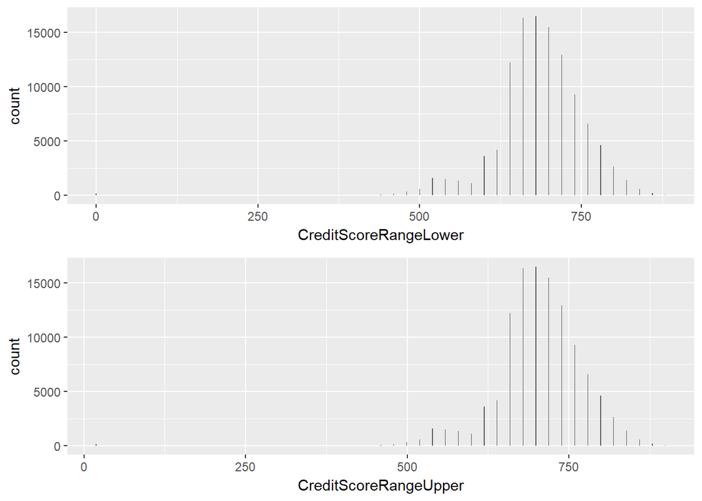

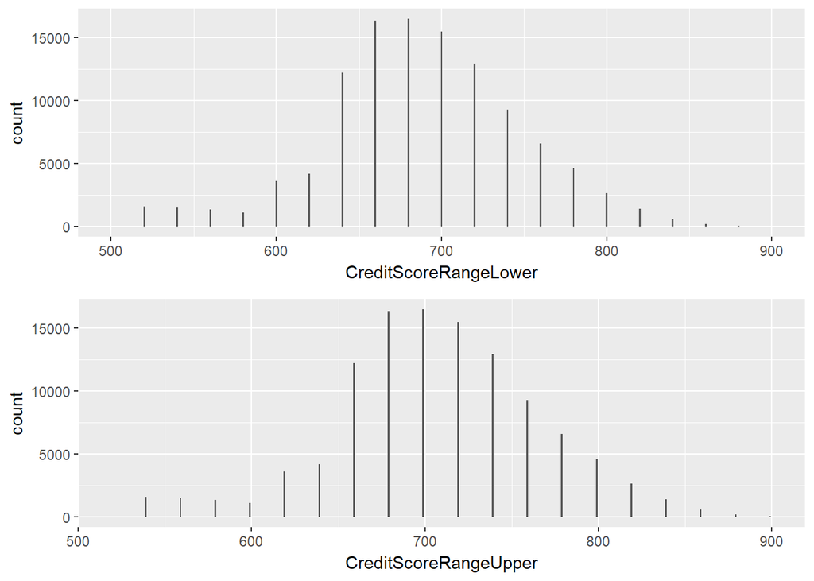

```
##
##     0   360   420   440   460   480   500   520   540   560   580   600
##   133     1     5    36   141   346   554  1593  1474  1357  1125  3602
##   620   640   660   680   700   720   740   760   780   800   820   840
##  4172 12199 16366 16492 15471 12923  9267  6606  4624  2644  1409   567
##   860   880
##   212    27
```

```
##
##    19   379   439   459   479   499   519   539   559   579   599   619
##   133     1     5    36   141   346   554  1593  1474  1357  1125  3602
##   639   659   679   699   719   739   759   779   799   819   839   859
##  4172 12199 16366 16492 15471 12923  9267  6606  4624  2644  1409   567
##   879   899
##   212    27
```

The credit score variables both have normal distributions that look identical, but shifted on the x-axis. Looking at the tables of the values, we can see that the lower credit scores all end in 0 and the upper scores all end in 9. The scores also increment by a factor of 20 and the upper credit scores are all higher than the lower scores by exactly 19. Since these values represent a credit score range that seems to vary by exactly 19 for each borrower, we will create a new variable CreditScore that is the mean of CreditScoreRangeLower and CreditScoreRangeUpper.

```
##    Min. 1st Qu.  Median    Mean 3rd Qu.    Max.    NA's
##     9.5   669.5   689.5   695.1   729.5   889.5     591
```

According to [ValuePenguin](https://www.valuepenguin.com/average-credit-score), the average credit score in the U.S. in 2014 was 693. Here we can see that the mean (695) and median (690) of the CreditScore in our data set are right around this value. I’m surprised to see here that the credit scores for those approved for loans is not higher than the average in the U.S. in 2014.

We can also see here that credit scores in our data set range from 9.5 to 889.5, but the actual range for credit scores is 300 to 850. Let’s explore some loans with credit scores outside the normal range.

```
##       Term LoanStatus BorrowerRate ProsperScore EmploymentStatus
## 795     36  Completed       0.2900           NA    Not available
## 913     36  Defaulted       0.2600           NA    Not available
## 1686    36       <NA>       0.1625           NA    Not available
## 4291    36       <NA>       0.2375           NA        No answer
## 4372    36  Defaulted       0.2325           NA    Not available
## 4431    36  Defaulted       0.1450           NA    Not available
## 4673    36       <NA>       0.1930           NA    Not available
## 5685    36  Completed       0.2300           NA    Not available
## 6878    36       <NA>       0.0700           NA    Not available
## 7740    36       <NA>       0.2900           NA    Not available
## 9049    36  Defaulted       0.2900           NA    Not available
## 9474    36       <NA>       0.2500           NA    Not available
## 13396   36  Defaulted       0.2375           NA        No answer
## 13526   36       <NA>       0.2000           NA    Not available
```

[output cut: 69 more lines]

```
##       Term LoanStatus BorrowerRate ProsperScore EmploymentStatus
## 186     36  Defaulted       0.2365            6    Self-employed
## 936     36  Completed       0.0499           NA        Full-time
## 1094    36    Current       0.0759            8         Employed
## 1402    36  Completed       0.0820           NA    Not available
## 1576    36    Current       0.0625           10         Employed
## 2024    36  Completed       0.3199            3    Self-employed
## 2117    36  Completed       0.0750           NA    Self-employed
## 2987    36  Completed       0.0695           NA          Retired
## 4083    36  Completed       0.0945            8        Full-time
## 4550    36  Completed       0.0854           10         Employed
## 6521    60    Current       0.0779           10         Employed
## 7183    36  Completed       0.0590           NA        Full-time
## 7449    12  Completed       0.0628            9          Retired
## 7475    36  Completed       0.1390            8         Employed
```

[output cut: 69 more lines]

These loans do seem to be missing a fair amount of values (there are a lot of Prosper scores missing), but since the data here do contain values for many of the variables I will not remove these rows. I will remember to subset the data for any plots or calculations involving credit score to only include scores from 300 to 850.

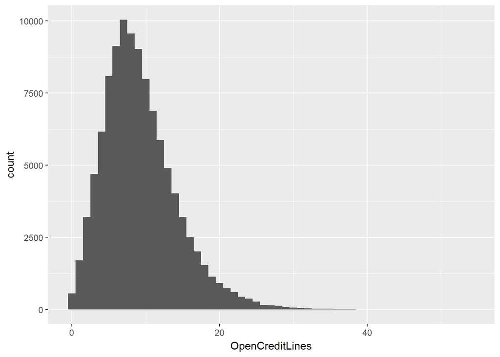

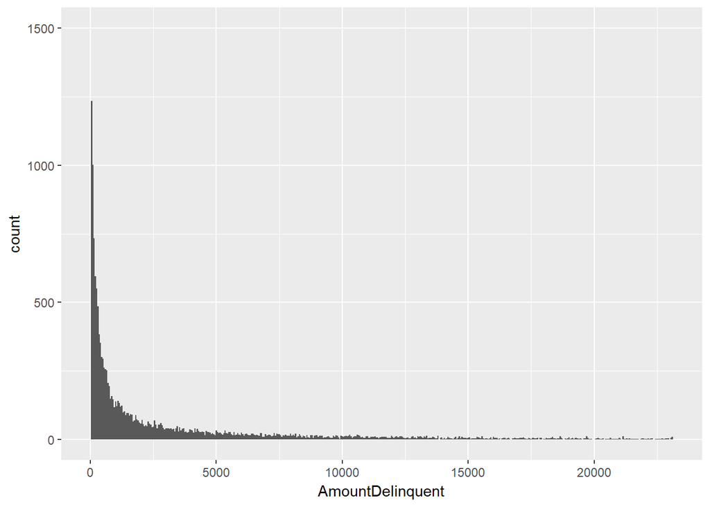

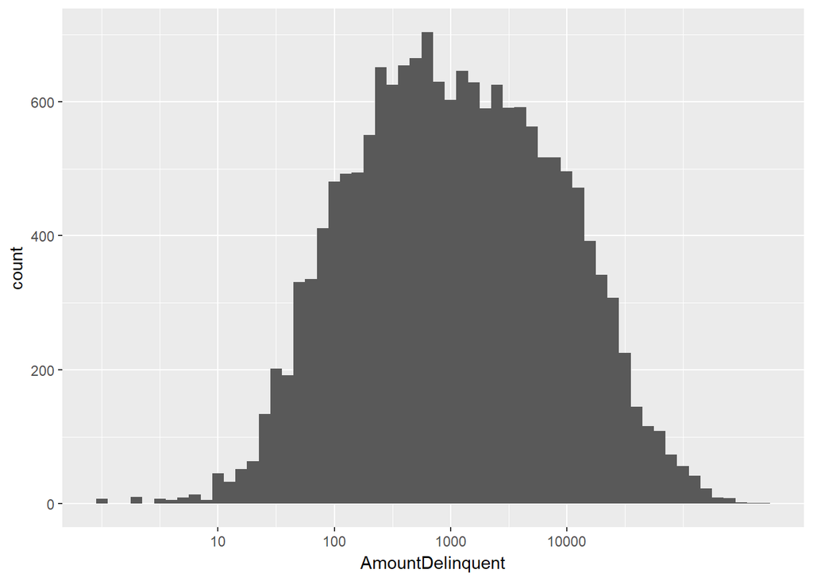

The number of open credit lines is a fairly normal distribution. Most people have less than 20 open credit lines. The distribution of amount delinquent is, alternatively, clearly skewed to the right. Most people are not deliquent at all. A log transformation of the AmountDelinquent data produces a normal distribution.

# Univariate Analysis

### What is the structure of your dataset?

The data set being analyzed contains 113,937 loans with 13 variables (Term, LoanStatus, MonthlyLoanPayment, ProsperScore, BorrowerRate, EmploymentStatus, IsBorrowerHomeowner, StatedMonthlyIncome, DebtToIncomeRatio, CreditScoreRangeLower, CreditScoreRangeUpper, OpenCreditLines, and AmountDelinquent).

The original data set contained 81 variables, but in this project we are focusing on 13 variables of interest.

Some initial observations from the data are: - Most loans have a 36 month term - Borrower rate peaks around 0.15, but also again around 0.31 - The median upper credit score is about the same as the average U.S credit score - There are extreme values in the debt to income ratio at 10.01 - Some monthly loan payments are much higher than average - Some Prosper scores are an 11, outside the scale of 1-10

### What is/are the main feature(s) of interest in your dataset?

The main feature of interest is ProsperScore. I want to explore how the borrower profile such as EmploymentStatus, CreditScore, and StatedMonthlyIncome affect the ProsperScore. Also, I want to see how ProsperScore relates to the loan details such as BorrowerRate, MonthlyLoanPayment, and LoanStatus.

### What other features in the dataset do you think will help support your investigation into your feature(s) of interest?

As stated above, I think the variables relating to the borrower’s profile will all contribute to the ProsperScore. I think the CreditScore, StatedMonthlyIncome, and DebtToIncomeRatio will contribute the most. Further, I think the ProsperScore will correlate with the BorrowerRate and MonthlyLoanPayment, and will be predictive of the LoanStatus.

### Did you create any new variables from existing variables in the dataset?

I created CreditScore by taking the average of the upper and lower credit scores, and I made Term a factor variable since the numerical values fell within 3 distinct categories. I also ordered the EmploymentStatus and LoanStatus factors based on my perception of best to worst from the view of the loan company.

### Of the features you investigated, were there any unusual distributions? Did you perform any operations on the data to tidy, adjust, or change the form of the data? If so, why did you do this?

I performed a log transformation on the StatedMonthlyIncome and AmountDelinquent since the data in both plots was skewed to the right. I wanted to see if the log transformation would normalize the data. The transformed data did create a more normal looking distribution for both variables.

# Bivariate Plots Section

```
##                     BorrowerRate ProsperScore OpenCreditLines
## BorrowerRate                1.00        -0.66           -0.11
## ProsperScore               -0.66         1.00           -0.01
## OpenCreditLines            -0.11        -0.01            1.00
## AmountDelinquent            0.05        -0.04           -0.06
## DebtToIncomeRatio           0.13        -0.14            0.15
## StatedMonthlyIncome        -0.15         0.16            0.19
## MonthlyLoanPayment         -0.33         0.18            0.19
## CreditScore                -0.53         0.38            0.10
##                     AmountDelinquent DebtToIncomeRatio StatedMonthlyIncome
## BorrowerRate                    0.05              0.13               -0.15
## ProsperScore                   -0.04             -0.14                0.16
## OpenCreditLines                -0.06              0.15                0.19
## AmountDelinquent                1.00             -0.03                0.02
## DebtToIncomeRatio              -0.03              1.00               -0.14
## StatedMonthlyIncome             0.02             -0.14                1.00
## MonthlyLoanPayment             -0.02              0.00                0.30
## CreditScore                    -0.05             -0.01                0.10
##                     MonthlyLoanPayment CreditScore
## BorrowerRate                     -0.33       -0.53
## ProsperScore                      0.18        0.38
## OpenCreditLines                   0.19        0.10
## AmountDelinquent                 -0.02       -0.05
## DebtToIncomeRatio                 0.00       -0.01
## StatedMonthlyIncome               0.30        0.10
## MonthlyLoanPayment                1.00        0.22
## CreditScore                       0.22        1.00
```

Borrower rate has a moderate (to strong) negative correlation with Prosper score and credit score. There are also weak relationships between some of the other variables. As credit score goes up, Prosper score tends to go up. A higher monthly loan payment also weakly correlates with a higher stated monthly income and a lower borrower rate. Borrower rate seems to have moderately strong correlations with the most variables.

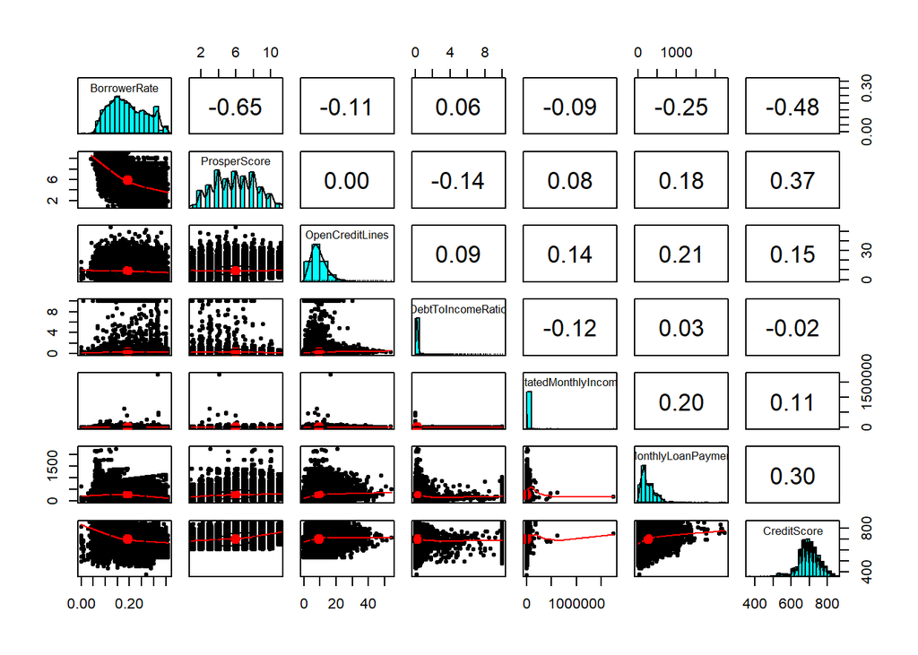

The Prosper score seems to be moderately correlated with borrower rate (negatively) and credit score. Credit score also seems to be moderately correlated with monthly loan payment and negatively with borrower rate.

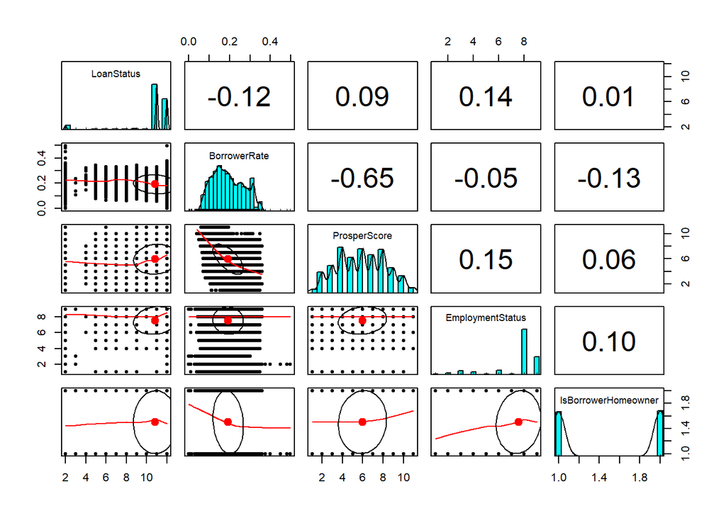

There don’t seem to be any obvious relationships between Prosper score and any of the categorical variables. I also included borrower rate to see if any of the categorical variables correlated with it, but the relationships are weak.

I want to take a closer look at the relationships between Prosper score and the variables borrower rate, monthly loan payment, credit score, and debt to income ratio.

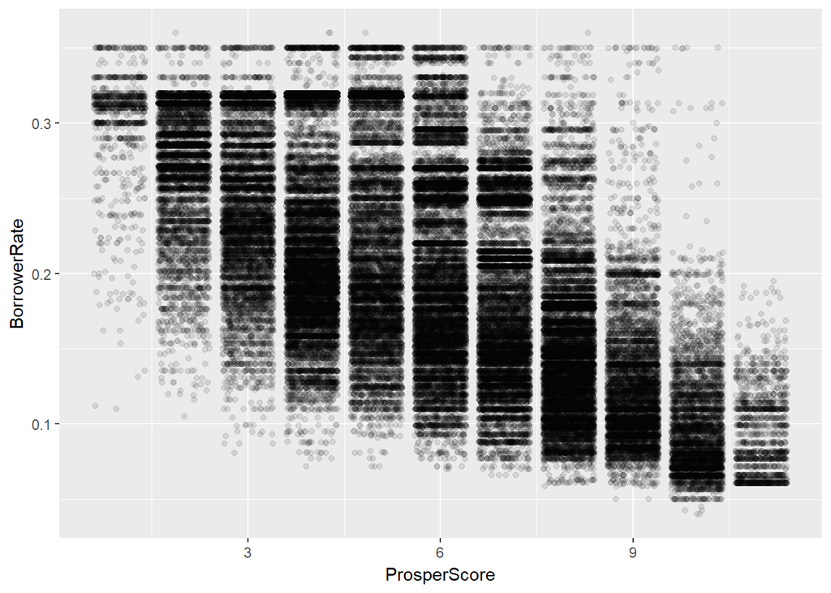

As Prosper score increases, borrower rate tends to decrease. At the low end and high end of the x-axis the range in borrower rate is lower. In the middle of the plot (Prosper score of 4-8) we can see a much bigger range in the borrower rate.

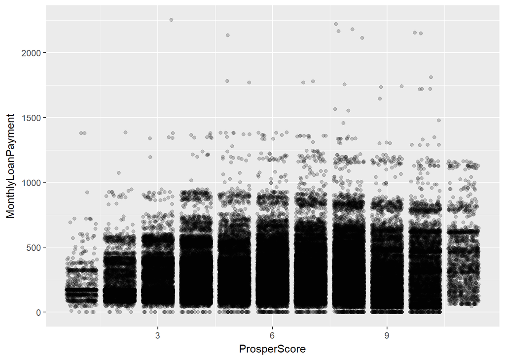

The slight upward trend in monthly loan payment as Prosper score increases can be seen here. It’s also fairly clear that as Prosper score increases, the biggest change to monthly loan payments is a wider range and greater volume of values. We don’t see many monthly loan payments greater than $500 for Prosper scores of 1-3, but the distribution of monthly loan payments for Prosper scores greater than 3 do not differ much as the score increases. Basically, borrowers with low Prosper scores do not get loans with high monthly payments.

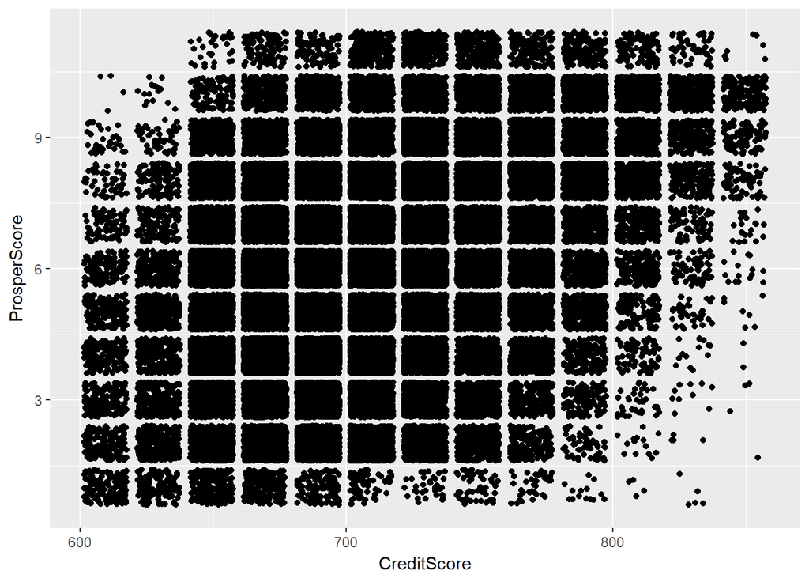

Similarly to the borrower rate, a low Prosper score typically corresponds to a low credit score and a high Prosper score with a high credit score, but the middle range of Prosper scores correspond to a wide range of credit scores. In other words, it’s unlikely for a borrower with a low credit score to have a high Prosper score, and vice versa for a borrower with a high credit score. If the borrower has a middle range credit score (650-750), their Prosper score can range vastly.

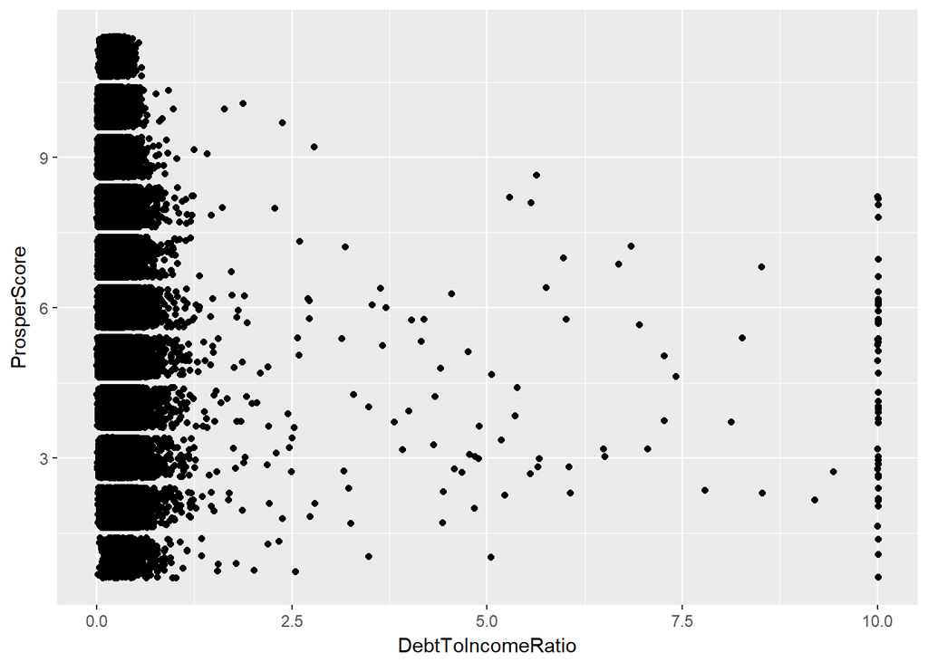

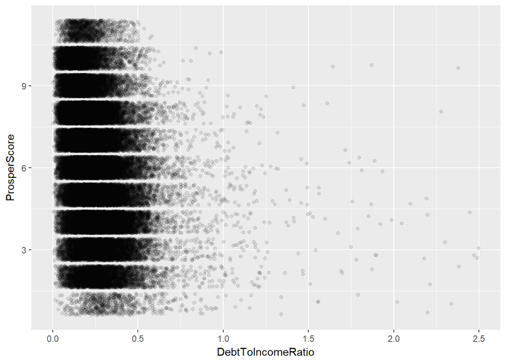

Here we can see the slight negative correlation between debt to income ratio and Prosper score.

Let us also take a look at borrower rate vs. monthly loan payment and credit score as these variables had moderate correlations with borrower rate.

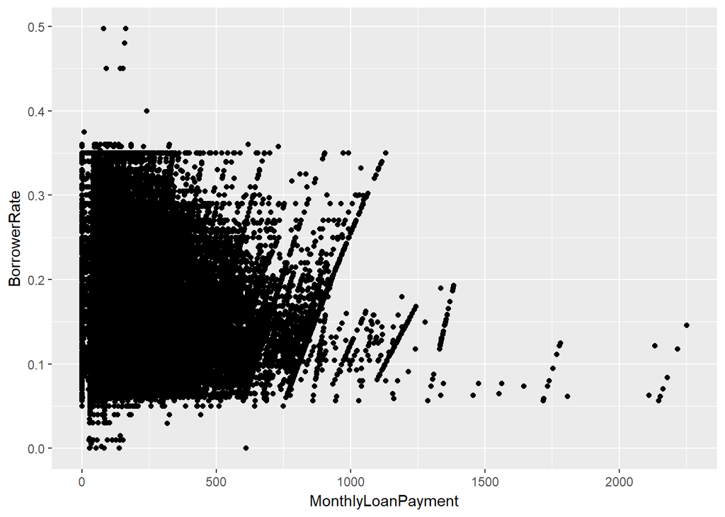

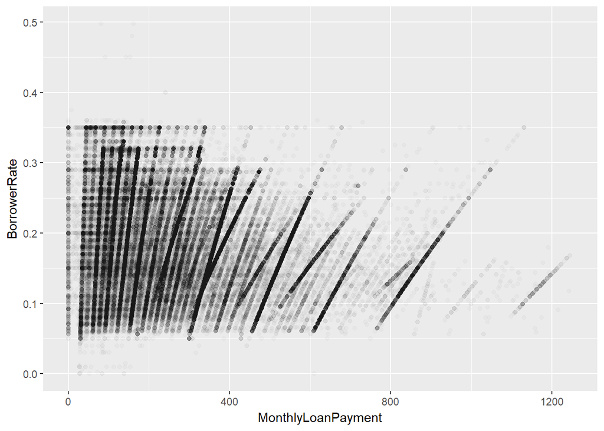

Changing the plot limits and adding transparency reveals clear sections of the plot where borrower rate increases linearly as the monthly loan payment increases. Also, the highest borrower rates tend to correspond to lower monthly payments. I wonder what may cause the borrower rate to increase without much or any increase to monthly loan payment.

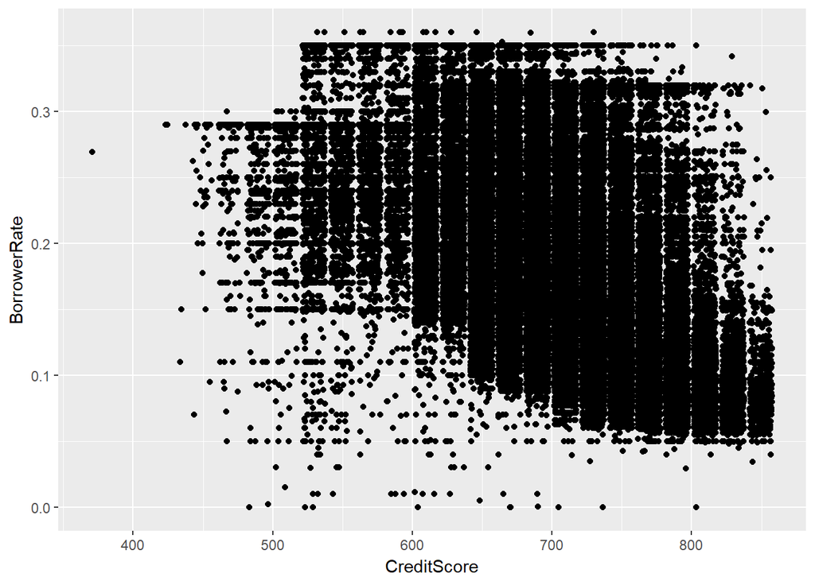

The correlation between credit score and borrower rate is clear here - as credit score increases, borrower rate decreases.

Next, I’ll look at how Prosper score and borrower rate may fluctuate based on the categorical variables (loan status, employment, and homeowners). It is important to remember here that the loan status and employment status levels were ordered by my own thoughts on levels of borrower risk and ideal loan outcomes.

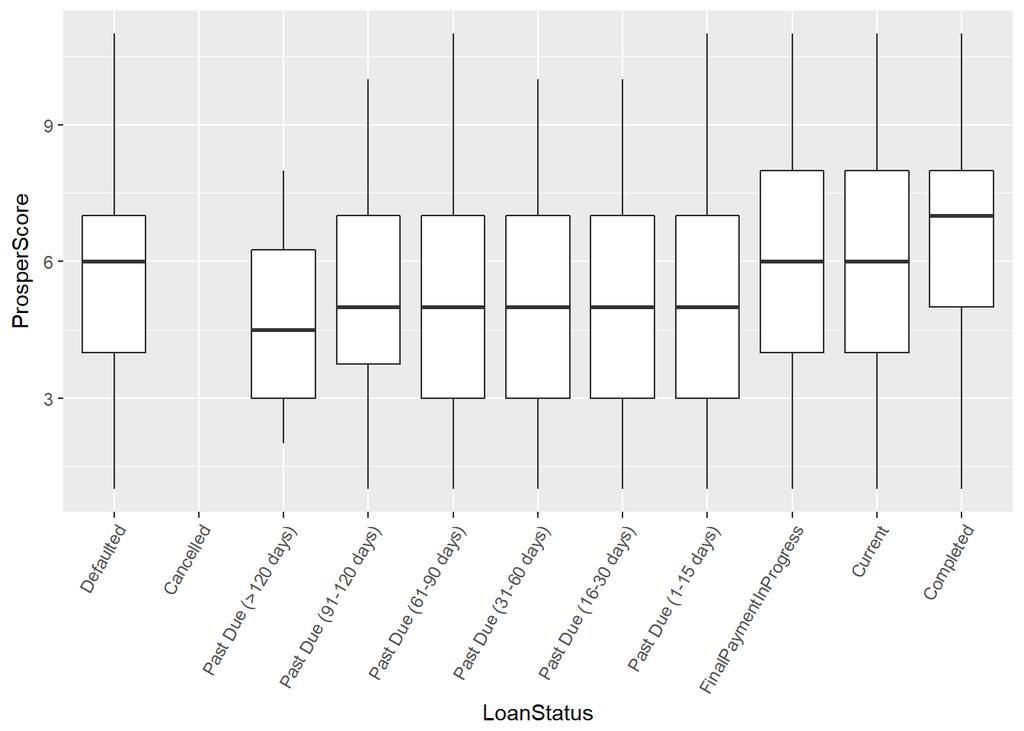

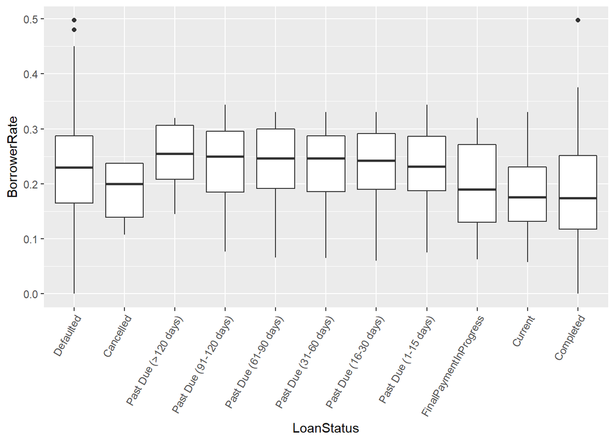

As mentioned above, it’s important to remember that the order of these levels was determined by my own judgment. There is a slight upward trend in Prosper score across loan status, but the defaulted loans Prosper score values seem to throw off this trend. There also may be a slight downward trend in borrower rate across loan status, but it is not strong at all.

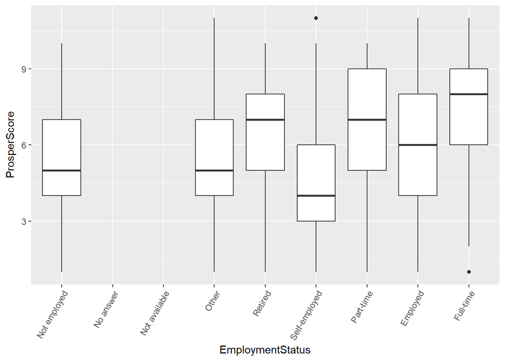

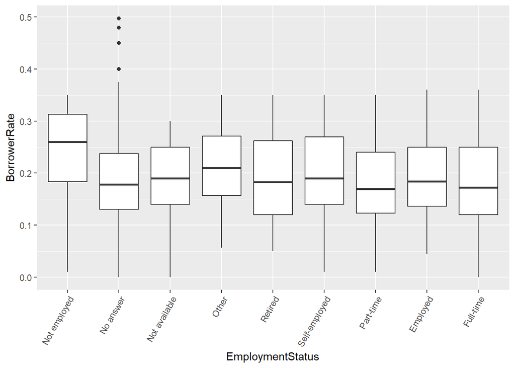

Lower average Prosper scores can be seen for borrowers with employment statuses of not employed, other, and self-employed, while higher average scores correspond with retired, part-time and full-time. Based on this, I will begin treating employment status as a nominal variable. Trying to order the employment status categories does not seem feasible any longer.

The borrower rate is generally higher for those that are not employed, but otherwise there isn’t much difference across employment levels.

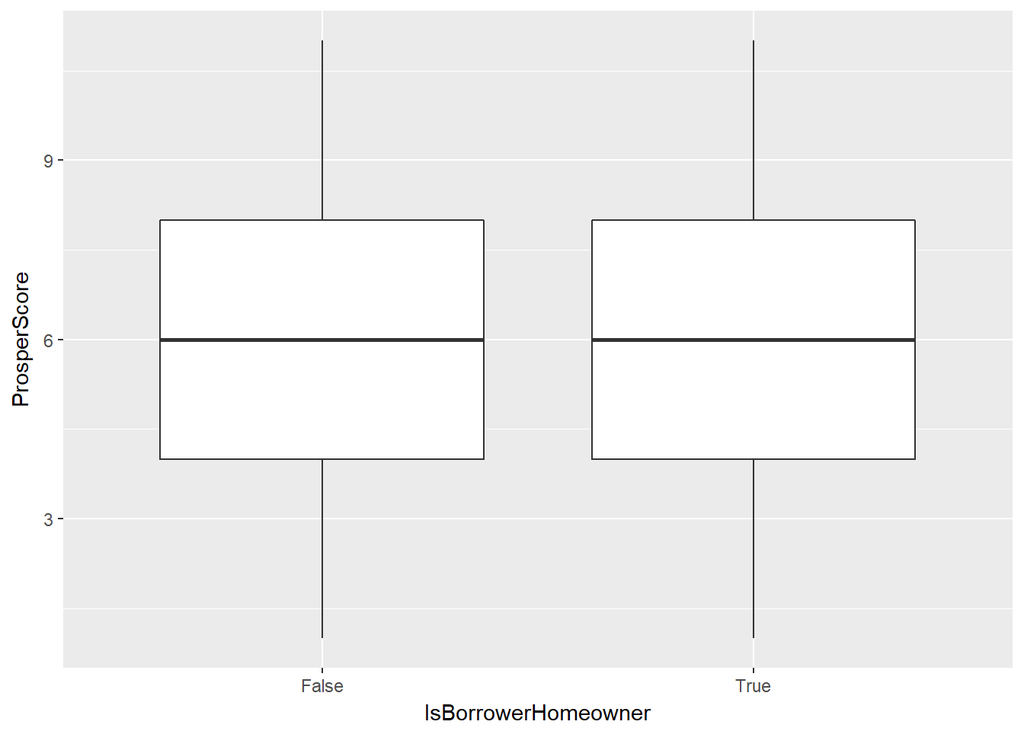

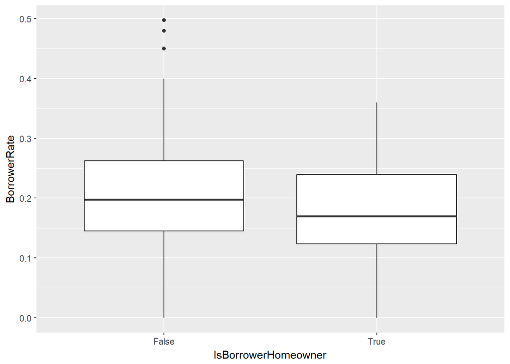

The borrower’s status as a homeowner does not appear to affect the Prosper score at all, but not owning a home does seem to correspond with a higher borrower rate.

# Bivariate Analysis

### Talk about some of the relationships you observed in this part of the investigation. How did the feature(s) of interest vary with other features in the dataset?

The Prosper score and borrower rate had a moderate negative correlation, with the borrower rate decreasing as Prosper score increased. There was a big range of values in the middle section of Prosper scores (and the middle section of borrower rates).

Low Prosper scores make it highly unlikely that the monthly loan payment will be greater than $500.

A well-below average credit score generally corresponds to a low Prosper score, and a well-above average credit score generally corresponds to a high Prosper score. A credit score between 650-750, on the other hand, corresponds to Prosper scores that can range vastly.

Debt to income ratio increases tended to weakly correlate with lower Prosper scores.

There was a slight upward trend in Prosper score across loan status, but the defaulted loans Prosper score values seem to throw off this trend.

Lower average Prosper scores can be seen for borrowers with employment statuses of not employed, other, and self-employed, while higher average scores correspond with retired, part-time and full-time.

It was surprising to see that being a homeowner had no affect on Prosper score.

### Did you observe any interesting relationships between the other features (not the main feature(s) of interest)?

Borrower rate tends to decrease as credit score increases, which makes sense. I was also very interested in the plot between borrower rate and monthly loan payment. There were clear segments that showed sectional linear relationships between borrower rate and monthly loan payment. I’m wondering if the distinction of these sections corresponds to any other variables, or if the linear relationships are affected by another variable.

### What was the strongest relationship you found?

The strongest bivariate relationship was between borrower rate and Prosper score. Credit score also had a fairly strong correlation with borrower rate.